# Tugas Pertemuan 67

Muhammad Bagas Ramadhan G1401231109

2025-10-26

# BAGIAN 1: PERSIAPAN

```r
library(ggplot2)
library(tsibble, lib.loc = "~/R/libs")
library(tseries)
library(MASS)
library(openxlsx, lib.loc = "~/R/libs")
data_full <- read.xlsx("C:/Users/AKU/Downloads/Data MPDWW.xlsx")
data_lengkap <- data_full[, 2]
data_bagas <- data_lengkap[361:540] |> ts()
```

# BAGIAN 2: ANALISIS STASIONERITAS

```r
# Statistik Deskriptif Dasar
print(paste("Rata-rata:", mean(data_bagas)))
```

```
## [1] "Rata-rata: 373.701277777778"
```

```r
print(paste("Varians:", var(data_bagas)))
```

```
## [1] "Varians: 73.1902447268777"
```

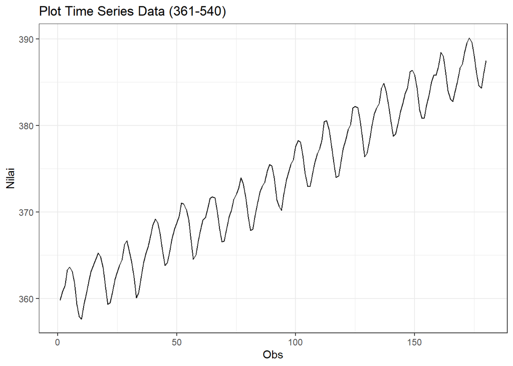

```r
# Plot Time Series
plot_ts_bagas <- data_bagas |>
  as_tsibble() |>
  ggplot(aes(x = index, y = value)) +
  geom_line() +
  theme_bw() +
  xlab("Obs") +
  ylab("Nilai") +
  ggtitle("Plot Time Series Data (361-540)")

plot_ts_bagas
```

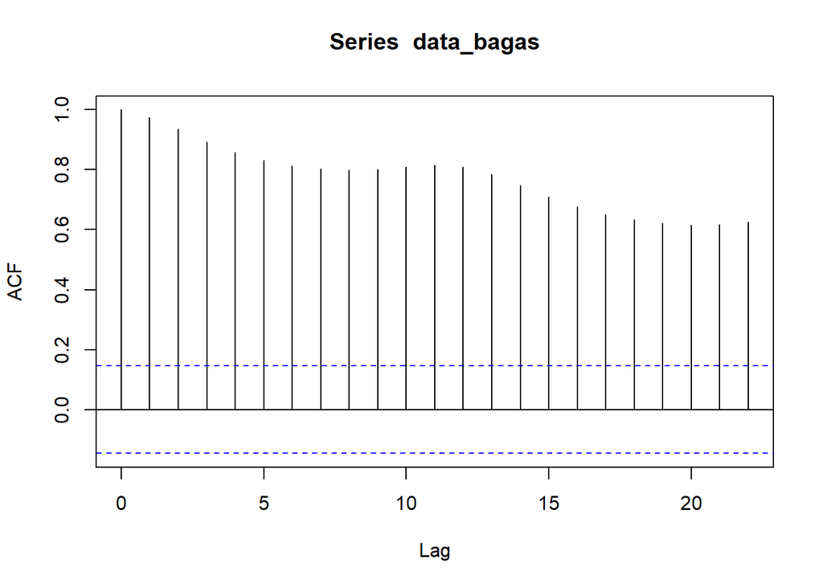

```r
# Plot ACF (Autocorrelation Function)
# Melihat apakah data tidak stasioner dalam rataan
acf(data_bagas)
```

```r
# Uji ADF (Augmented Dickey-Fuller)
# Uji statistik untuk stasioneritas rataan
tseries::adf.test(data_bagas)
```

```
##
##  Augmented Dickey-Fuller Test
##
## data:  data_bagas
## Dickey-Fuller = -11.184, Lag order = 5, p-value = 0.01
## alternative hypothesis: stationary
```

```r
# Uji Box-Cox
# Uji statistik untuk stasioneritas ragam
data_bagas_shifted <- data_bagas

if (min(data_bagas) <= 0) {
  # Jika ada data non-positif, geser data
  data_bagas_shifted <- data_bagas - min(data_bagas) + 1
  "Data digeser karena ada nilai non-positif."
} else {
  "Data sudah positif, tidak perlu digeser."
}
```

```
## [1] "Data sudah positif, tidak perlu digeser."
```

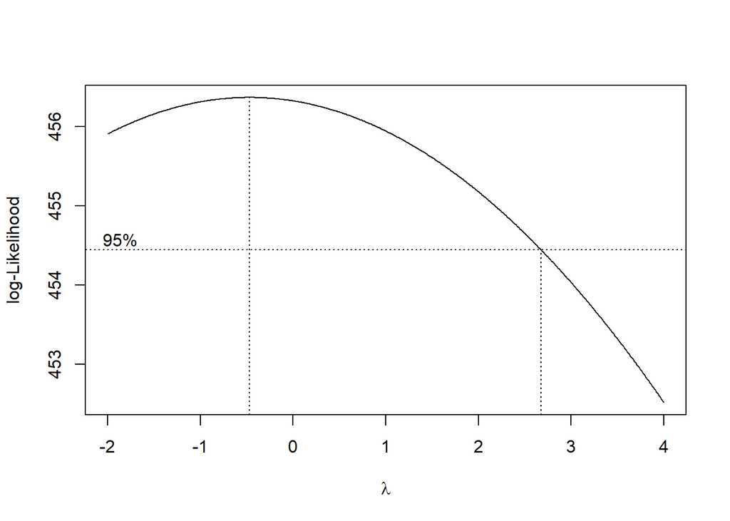

```r
# Membuat variabel index untuk uji Box-Cox
index_bagas <- seq(1, length(data_bagas_shifted))

# Menjalankan Uji Box-Cox
bc <- boxcox(data_bagas_shifted ~ index_bagas, lambda = seq(-2, 4, by = 0.01))
```

```r
# Mencari nilai lambda optimum
lambda_optimum <- bc$x[which.max(bc$y)]
paste("Lambda Optimum:", round(lambda_optimum, 3))
```

```
## [1] "Lambda Optimum: -0.47"
```

```r
# Mencari Selang Kepercayaan (SK) 95% untuk lambda
ci_lambda <- bc$x[bc$y > max(bc$y) - 0.5 * qchisq(0.95, 1)]
ci_lower <- min(ci_lambda)
ci_upper <- max(ci_lambda)
paste("SK 95% Lambda:", round(ci_lower, 3), "sampai", round(ci_upper, 3))
```

```
## [1] "SK 95% Lambda: -2 sampai 2.67"
```

Data stasioner dalam ragam, namun tidak stasioner dalam rataan.

Temuan ini bertentangan dengan hasil Uji ADF Anda sebelumnya (yang menunjukkan p-value = 0.01 atau stasioner). Dalam analisis time series, ketika plot visual ACF menunjukkan pola tails off yang sangat jelas, ini sering dianggap sebagai bukti non-stasioneritas yang lebih kuat daripada Uji ADF.

Oleh karena itu, kita akan memprioritaskan bukti visual dari plot ACF.

# BAGIAN 3: PENANGANAN

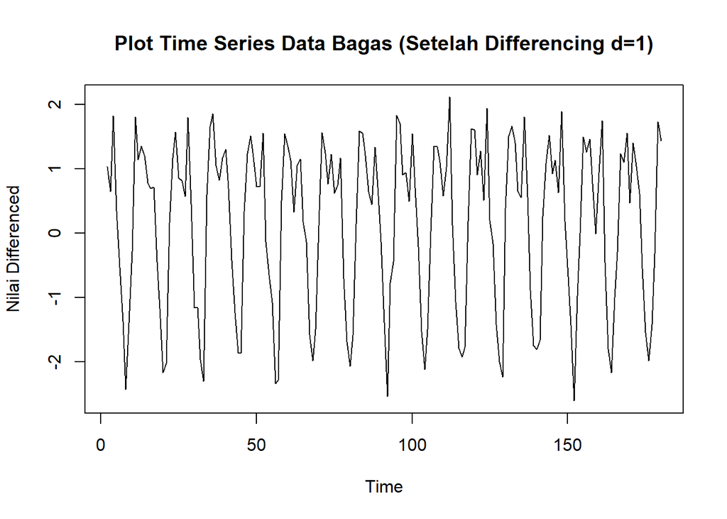

```r
# Melakukan Differencing Orde 1 (d=1)
data_bagas_diff1 <- diff(data_bagas, differences = 1)


# Validasi Hasil Differencing
# a. Plot Time Series (Data Hasil Differencing)
ts.plot(data_bagas_diff1,
        main = "Plot Time Series Data Bagas (Setelah Differencing d=1)",
        ylab = "Nilai Differenced")
```

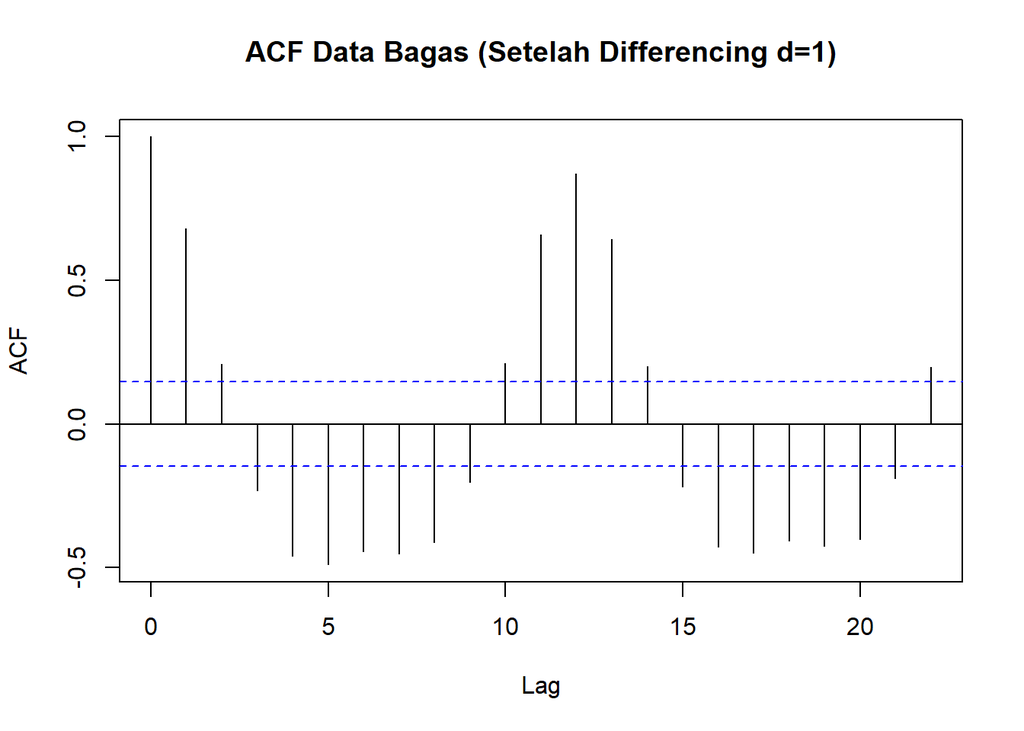

```r
# b. Plot ACF (Data Hasil Differencing)
acf(data_bagas_diff1, main = "ACF Data Bagas (Setelah Differencing d=1)")
```

```r
# c. Uji ADF (Data Hasil Differencing)
tseries::adf.test(data_bagas_diff1)
```

```
##
##  Augmented Dickey-Fuller Test
##
## data:  data_bagas_diff1
## Dickey-Fuller = -9.397, Lag order = 5, p-value = 0.01
## alternative hypothesis: stationary
```

## Uji ADF (Secara Statistik):

Uji ADF pada data baru menghasilkan p-value = 0.01 1.

Karena p-value (0.01) < 0.05, kita Tolak $H_0$. Ini membuktikan bahwa data yang telah di-differencing SUDAH STASIONER dalam rataan2.

## Plot Time Series (Secara Visual):

Plot Time Series baru tidak lagi menunjukkan tren naik.

Datanya sekarang terlihat acak dan berfluktuasi di sekitar nilai tengah (nol), yang merupakan ciri data stasioner.

# Model ARIMA

```r
# Menggunakan auto.arima
library(forecast)
model_otomatis <- auto.arima(data_bagas, trace=TRUE)
```

```
##
##  Fitting models using approximations to speed things up...
##
##  ARIMA(2,1,2) with drift         : 443.0144
##  ARIMA(0,1,0) with drift         : 601.2028
##  ARIMA(1,1,0) with drift         : 491.8075
##  ARIMA(0,1,1) with drift         : 502.7996
##  ARIMA(0,1,0)                    : 601.7305
##  ARIMA(1,1,2) with drift         : 460.356
##  ARIMA(2,1,1) with drift         : Inf
##  ARIMA(3,1,2) with drift         : 399.7745
##  ARIMA(3,1,1) with drift         : 412.2864
##  ARIMA(4,1,2) with drift         : Inf
##  ARIMA(3,1,3) with drift         : 401.4254
##  ARIMA(2,1,3) with drift         : 433.7887
##  ARIMA(4,1,1) with drift         : Inf
##  ARIMA(4,1,3) with drift         : Inf
##  ARIMA(3,1,2)                    : 420.8828
##
##  Now re-fitting the best model(s) without approximations...
##
##  ARIMA(3,1,2) with drift         : Inf
##  ARIMA(3,1,3) with drift         : Inf
##  ARIMA(3,1,1) with drift         : Inf
##  ARIMA(3,1,2)                    : 420.6151
##
##  Best model: ARIMA(3,1,2)
```

```r
model_otomatis
```

```
## Series: data_bagas
## ARIMA(3,1,2)
##
## Coefficients:
##          ar1    ar2      ar3     ma1      ma2
##       0.5689  0.606  -0.7651  0.1379  -0.6963
## s.e.  0.0787  0.100   0.0651  0.0838   0.0711
##
## sigma^2 = 0.5831:  log likelihood = -204.06
## AIC=420.13   AICc=420.62   BIC=439.25
```

# Uji Model Otomatis

```r
library(lmtest)
# Uji signifikansi parameter
lmtest::coeftest(model_otomatis)
```

```
##
## z test of coefficients:
##
##      Estimate Std. Error  z value  Pr(>|z|)
## ar1  0.568922   0.078738   7.2255 4.991e-13 ***
## ar2  0.605991   0.099999   6.0600 1.361e-09 ***
## ar3 -0.765125   0.065068 -11.7589 < 2.2e-16 ***
## ma1  0.137931   0.083801   1.6459   0.09978 .
## ma2 -0.696302   0.071098  -9.7935 < 2.2e-16 ***
## ---
## Signif. codes:  0 '***' 0.001 '**' 0.01 '*' 0.05 '.' 0.1 ' ' 1
```

```r
# Uji Diagnostik Sisaan
Box.test(model_otomatis$residuals, lag=24, type="Ljung-Box")
```

```
##
##  Box-Ljung test
##
## data:  model_otomatis$residuals
## X-squared = 268.01, df = 24, p-value < 2.2e-16
```

```r
shapiro.test(model_otomatis$residuals)
```

```
##
##  Shapiro-Wilk normality test
##
## data:  model_otomatis$residuals
## W = 0.9692, p-value = 0.0005175
```

Analisis Hasil Model yang dipilih oleh auto.arima (ARIMA(3,1,2)) telah GAGAL dalam pengujian. Model ini tidak baik dan tidak bisa kita terima untuk peramalan. karena GAGAL - Uji Signifikansi Parameter, GAGAL - Uji Independensi Sisaan / Ljung-Box, GAGAL - Uji Normalitas Sisaan / Shapiro-Wilk.

Kesimpulan Model yang disarankan oleh auto.arima DITOLAK.

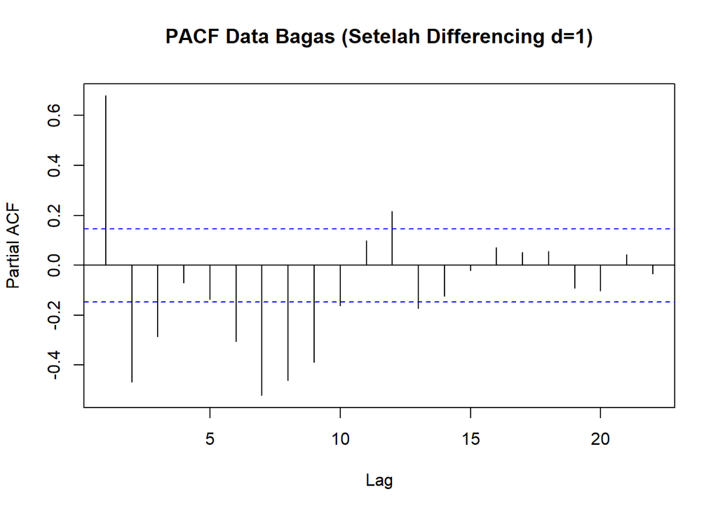

```r
# plot PACF dari data yang sudah stasioner
pacf(data_bagas_diff1, main="PACF Data Bagas (Setelah Differencing d=1)")
```

```r
model_111 <- arima(data_bagas, order = c(1, 1, 1))

lmtest::coeftest(model_111)
```

```
##
## z test of coefficients:
##
##     Estimate Std. Error z value  Pr(>|z|)
## ar1 0.538089   0.075291  7.1468 8.882e-13 ***
## ma1 0.362053   0.070006  5.1717 2.319e-07 ***
## ---
## Signif. codes:  0 '***' 0.001 '**' 0.01 '*' 0.05 '.' 0.1 ' ' 1
```